# Irish Times v3

JJayes

2022-06-02

## Irish times

There are three steps:

1. Construct query
2. Test that query works
3. Get the result of the query into R and extract information you want from it.

### Construct query

```r
library(tidyverse)
base <- "http://fedsearch.proquest.com/search/sru/"

# I can't use Irish times, instead I'll use globalwires
db <- "globalwires"

operation <- "?operation=searchRetrieve&version=1.2&maximumRecords=30&startRecord=1"

query_stub <- "&query=title%3D%22"

query_string <- "economic uncertainty"

query_string <- URLencode(query_string)

query <- str_c(query_stub, query_string)

all_together <- str_c(base, db, operation, query)

all_together
```

```
## [1] "http://fedsearch.proquest.com/search/sru/globalwires?operation=searchRetrieve&version=1.2&maximumRecords=30&startRecord=1&query=title%3D%22economic%20uncertainty"
```

### Test that query works

Now the URL in a browser should return a page that looks like this:

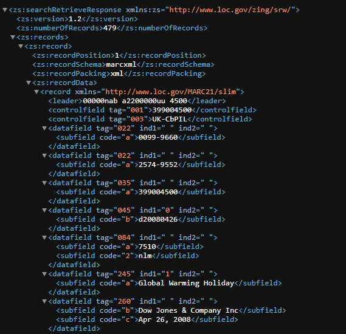

Screenshot of WSJ query in browser

```r
knitr::include_graphics("https://raw.githubusercontent.com/j-jayes/irish-uncertainty/main/images/html_return_wsj.PNG")
```

### Get the result of the query into R

To read this HTML into R, you can use the rvest package and the `read_html` command.

#### Using HTML and rvest

```r
library(rvest)
html <-read_html(all_together)

html
```

```
## {html_document}
## <html>
## [1] <body><searchretrieveresponse xmlns:zs="http://www.loc.gov/zing/srw/"><ve ...
```

This html document can be parsed with the `rvest` package where you choose the elements of the list you want with `html_elements`.

```r
html %>%
    html_elements('[tag="245"]') %>%
    html_text() %>%
    as_tibble() %>%
    rename(title = value)
```

```
## # A tibble: 30 x 1
##    title
##    <chr>
##  1 Canada's housing market strong globally but uncertainty could sideline buyers
##  2 Loonie declines amid Japanese economic uncertainty, lower equity markets
##  3 More market volatility expected amid European debt crisis, economic uncertai~
##  4 S. Korea faces growing economic uncertainties: finance ministry
##  5 London acknowledges Brexit will lead to economic uncertainty
##  6 Iranians face economic uncertainty, anxiety as US reimposes sanctions
##  7 Argentine president thanks Trump for support in times of economic uncertainty
##  8 China's Li says country must take stronger steps to face economic uncertainty
##  9 Economic uncertainty and unemployment expected to constrain RRSP contributio~
## 10 Astral Media Inc. expects economic uncertainty to affect radio, TV advertisi~
## # ... with 20 more rows
```

#### Using XML and the listviewer package.

Alternatively you can use XML

```r
library(XML)

xml <- XML::xmlParse(all_together)

list <- xml %>%
    XML::xmlToList(simplify = T)

listviewer::jsonedit(list)
```

[interactive chart not shown]

You then need to fiddle with the pluck command to get out the information you want into a dataframe. See the guide from Thomas Mock:

> This guide from [Thomas Mock](https://themockup.blog/posts/2020-05-22-parsing-json-in-r-with-jsonlite/) is super useful on how to parse the lists we get back and how to view them in R. Look towards the bottom of the post where he uses the [**purrr** package](https://purrr.tidyverse.org/).

```r
pluck(list, "records", 2, "recordData", "record") %>%
    # this command is great! wow!
    enframe() %>%
    filter(name == "datafield") %>%
    unnest_wider(value) %>%
    select(subfield) %>%
    unnest(subfield) %>%
    unnest_wider(subfield)
```

```
## # A tibble: 18 x 2
##    ...1                                                                    code
##    <chr>                                                                   <chr>
##  1 857316728                                                               <NA>
##  2 <NA>                                                                    a
##  3 d20110314                                                               <NA>
##  4 <NA>                                                                    b
##  5 Morrison, Malcolm                                                       <NA>
##  6 <NA>                                                                    a
##  7 Loonie declines amid Japanese economic uncertainty, lower equity marke~ <NA>
##  8 <NA>                                                                    a
##  9 NEWSPAPER                                                               <NA>
## 10 <NA>                                                                    a
## 11 Japan is the world's third-largest crude consumer at 4.5 million barre~ <NA>
## 12 <NA>                                                                    a
## 13 Petroleum industry                                                      <NA>
## 14 <NA>                                                                    a
## 15 Production capacity                                                     <NA>
## 16 <NA>                                                                    a
## 17 Canadian dollar                                                         <NA>
## 18 <NA>                                                                    a
```